# Tugas MPDW

# Library/Packages

```r
library(forecast)
```

```r
library(graphics)
library(TTR)
library(TSA)
library(rio)
library(ggplot2)
```

# Import Data

Data yang digunakan adalah **Data Beijing Air Quality**. Data terdiri atas dua variabel, yaitu `Periode` yang menunjukkan urutan periode pengamatan dan `Count` yang menunjukkan jumlah pengamatan pada setiap periode. Pada tugas ini digunakan bagian data **periode 195 sampai 388** sesuai dengan pembagian data kelompok.

```r
# Import data
data1 <- import("Beijing_Air_Quality_Rapi.csv")

# Melihat struktur data
head(data1)
```

```
##   Periode Count
## 1       1   263
## 2       2   270
## 3       3   259
## 4       4   281
## 5       5   267
## 6       6   244
```

```r
str(data1)
```

```
## 'data.frame':    970 obs. of  2 variables:
##  $ Periode: int  1 2 3 4 5 6 7 8 9 10 ...
##  $ Count  : int  263 270 259 281 267 244 258 286 288 280 ...
```

## 1. Mengambil Data Periode 195–388

```r
# Mengambil observasi periode 195 sampai 388
data2 <- subset(data1, Periode >= 195 & Periode <= 388)

# Mengurutkan berdasarkan periode
data2 <- data2[order(data2$Periode), ]

# Cek ukuran data
dim(data2)
```

```
## [1] 194   2
```

```r
# Cek data awal dan akhir
head(data2)
```

```
##     Periode Count
## 195     195   275
## 196     196   280
## 197     197   232
## 198     198   285
## 199     199   258
## 200     200   272
```

```r
tail(data2)
```

```
##     Periode Count
## 383     383   281
## 384     384   288
## 385     385   280
## 386     386   281
## 387     387   283
## 388     388   288
```

Data yang digunakan terdiri atas **194 observasi**, yaitu periode 195 sampai 388. Variabel yang digunakan dalam analisis deret waktu adalah `Count`.

# Eksplorasi Data

Eksplorasi data dilakukan untuk melihat struktur, ukuran, ringkasan, serta pola deret waktu pada data periode 195–388.

```r
View(data2)
str(data2)
```

```
## 'data.frame':    194 obs. of  2 variables:
##  $ Periode: int  195 196 197 198 199 200 201 202 203 204 ...
##  $ Count  : int  275 280 232 285 258 272 281 285 209 282 ...
```

```r
dim(data2)
```

```
## [1] 194   2
```

Mengubah variabel `Count` menjadi objek deret waktu menggunakan fungsi `ts()`.

```r
data.ts <- ts(data2$Count)
```

Menampilkan ringkasan data.

```r
summary(data.ts)
```

```
##    Min. 1st Qu.  Median    Mean 3rd Qu.    Max.
##    74.0   264.0   281.5   265.6   286.0   288.0
```

## 1. Plot Deret Waktu

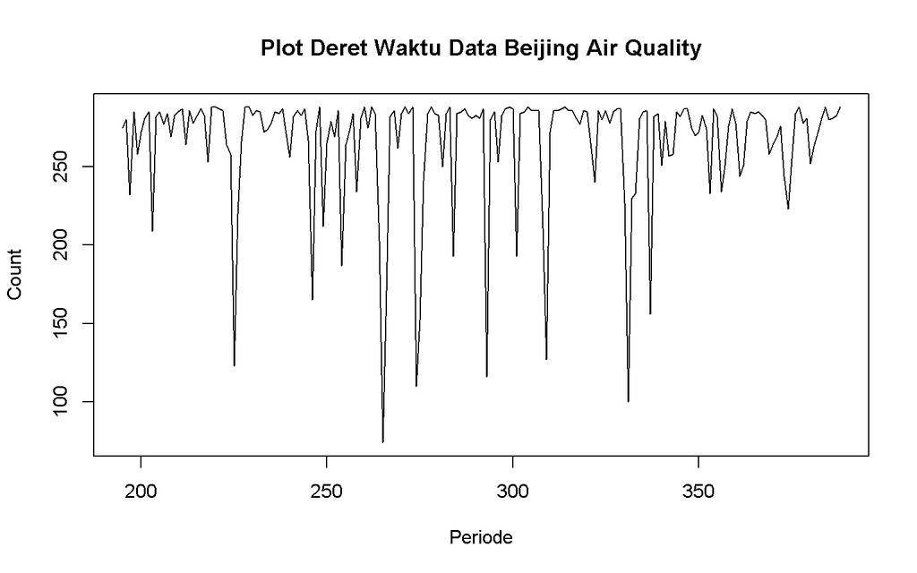

```r
plot(
  data2$Periode,
  data2$Count,
  type = "l",
  xlab = "Periode",
  ylab = "Count",
  main = "Plot Deret Waktu Data Beijing Air Quality"
)
```

Berdasarkan plot deret waktu, nilai `Count` mengalami fluktuasi dari satu periode ke periode berikutnya. Sebagian besar nilai berada pada kisaran yang relatif tinggi, tetapi terdapat beberapa periode dengan nilai yang jauh lebih rendah. Pola tersebut menunjukkan bahwa data memiliki perubahan nilai yang cukup besar pada beberapa periode tertentu.

# Pembagian Data Latih dan Data Uji

Pembagian data dilakukan dengan perbandingan **80% data latih dan 20% data uji**. Dari 194 observasi, sebanyak 155 observasi digunakan sebagai data latih dan 39 observasi digunakan sebagai data uji.

```r
# Jumlah observasi
n <- nrow(data2)

# Menentukan batas 80%
n_train <- floor(0.8 * n)

# Membagi data training dan testing
training <- data2[1:n_train, ]
testing <- data2[(n_train + 1):n, ]

# Mengubah menjadi time series
train.ts <- ts(training$Count)
test.ts <- ts(testing$Count)

# Mengecek jumlah observasi
length(train.ts)
```

```
## [1] 155
```

```r
length(test.ts)
```

```
## [1] 39
```

Data latih terdiri atas **155 observasi**, sedangkan data uji terdiri atas **39 observasi**. Data latih digunakan untuk membentuk model pemulusan, sedangkan data uji digunakan untuk mengevaluasi kemampuan model dalam melakukan peramalan pada data yang belum digunakan dalam proses pemodelan.

## Eksplorasi Data Latih dan Data Uji

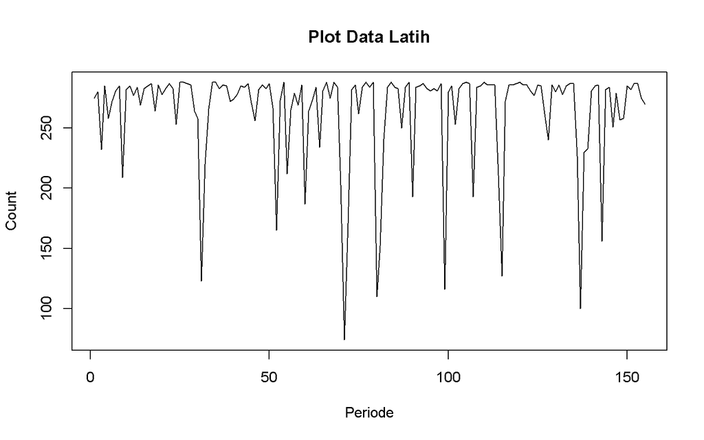

```r
# Plot data latih
plot(
  train.ts,
  type = "l",
  xlab = "Periode",
  ylab = "Count",
  main = "Plot Data Latih"
)
```

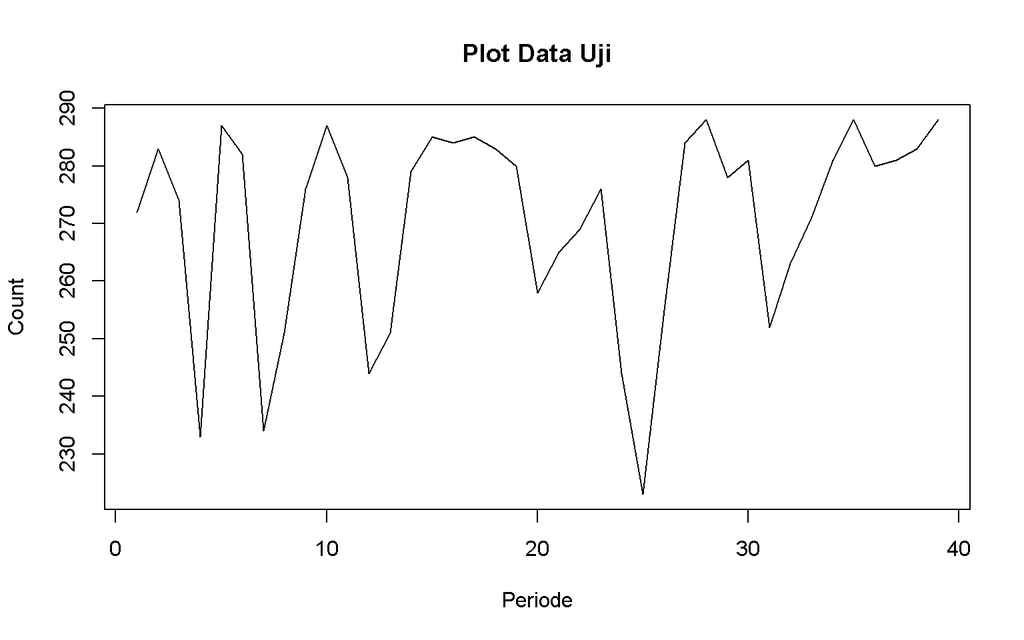

```r
# Plot data uji
plot(
  test.ts,
  type = "l",
  xlab = "Periode",
  ylab = "Count",
  main = "Plot Data Uji"
)
```

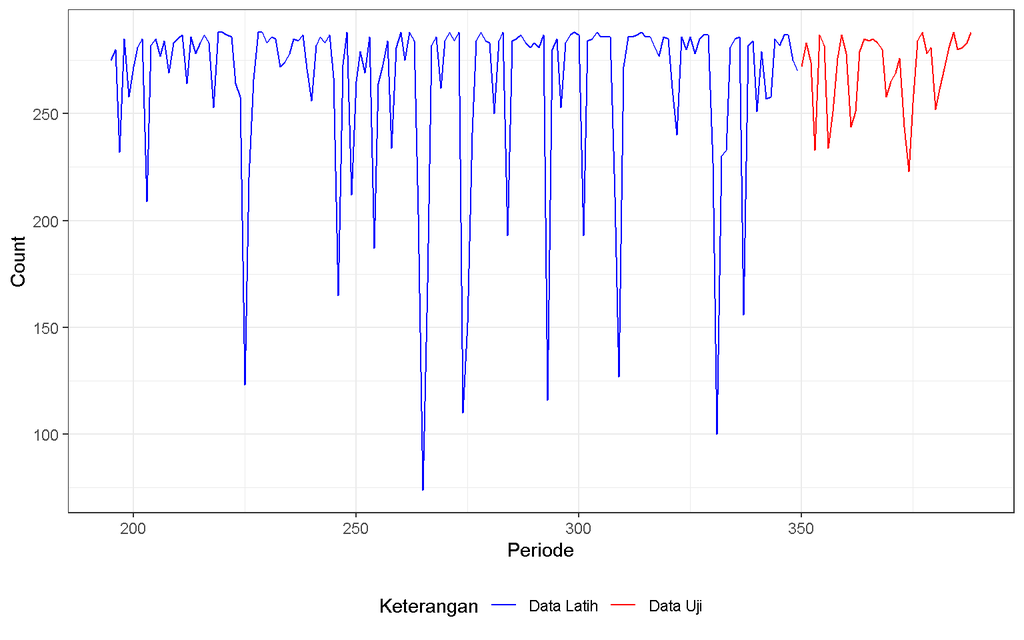

```r
ggplot() +
  geom_line(
    data = training,
    aes(x = Periode, y = Count, color = "Data Latih")
  ) +
  geom_line(
    data = testing,
    aes(x = Periode, y = Count, color = "Data Uji")
  ) +
  labs(
    x = "Periode",
    y = "Count",
    color = "Keterangan"
  ) +
  scale_colour_manual(
    values = c("Data Latih" = "blue", "Data Uji" = "red")
  ) +
  theme_bw() +
  theme(legend.position = "bottom")
```

# Moving Average

Moving Average merupakan metode pemulusan yang menggunakan beberapa pengamatan sebelumnya untuk memperoleh nilai pemulusan. Metode ini memberikan bobot yang sama pada setiap pengamatan yang termasuk dalam periode pemulusan. Pada analisis ini digunakan **m = 12** sebagai panjang periode moving average.

## 1. Single Moving Average (SMA)

Single Moving Average (SMA) merupakan metode pemulusan yang menghitung rata-rata dari sejumlah pengamatan terakhir. Nilai pemulusan pada periode ke-t diperoleh dari rata-rata m pengamatan sebelumnya.

$S_t = \frac{1}{m}\sum_{i=t-m+1}^{t}X_i$

Nilai pemulusan pada periode terakhir digunakan sebagai dasar untuk melakukan peramalan periode berikutnya.

```r
# Parameter SMA
m <- 12

# Pemulusan SMA
sma <- SMA(train.ts, n = m)

# Melihat hasil pemulusan
head(sma, 20)
```

```
## Time Series:
## Start = 1
## End = 20
## Frequency = 1
##  [1]       NA       NA       NA       NA       NA       NA       NA       NA
##  [9]       NA       NA       NA 268.4167 269.1667 268.2500 272.5000 272.5000
## [17] 274.9167 274.2500 274.6667 274.0833
```

Peramalan untuk data uji dilakukan dengan menggunakan nilai SMA terakhir sebagai nilai ramalan untuk periode-periode berikutnya.

```r
# Ramalan sebanyak jumlah data uji
forecast_sma <- rep(
  tail(na.omit(sma), 1),
  length(test.ts)
)

head(forecast_sma)
```

```
## [1] 274.75 274.75 274.75 274.75 274.75 274.75
```

## 2. Plot Hasil SMA

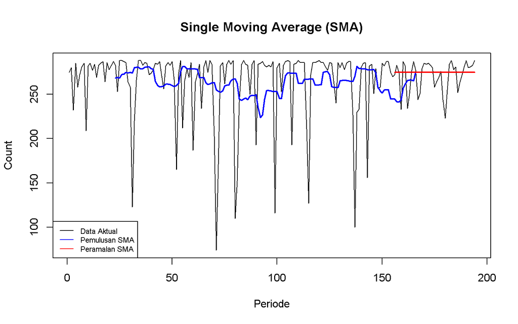

```r
plot(
  data.ts,
  type = "l",
  xlab = "Periode",
  ylab = "Count",
  main = "Single Moving Average (SMA)"
)

lines(
  c(rep(NA, m - 1), sma),
  col = "blue",
  lwd = 2
)

lines(
  c(
    rep(NA, length(train.ts)),
    forecast_sma
  ),
  col = "red",
  lwd = 2
)

legend(
  "bottomleft",
  c("Data Aktual", "Pemulusan SMA", "Peramalan SMA"),
  col = c("black", "blue", "red"),
  lty = 1,
  cex = 0.7
)
```

## 3. Akurasi SMA

Perhitungan akurasi dilakukan menggunakan ukuran **SSE, MSE, RMSE, dan MAPE**. Semakin kecil nilai ukuran kesalahan, semakin baik kemampuan model dalam melakukan peramalan.

$SSE = \sum_{t=1}^{n}(y_t-\hat{y}_t)^2$

$MSE = \frac{1}{n}\sum_{t=1}^{n}(y_t-\hat{y}_t)^2$

$RMSE = \sqrt{MSE}$

$MAPE = \frac{1}{n}\sum_{t=1}^{n}\left|\frac{y_t-\hat{y}_t}{y_t}\right|\times100$

```r
# Error SMA pada data uji
error_sma <- test.ts - forecast_sma

# SSE
SSE_sma <- sum(error_sma^2)

# MSE
MSE_sma <- mean(error_sma^2)

# RMSE
RMSE_sma <- sqrt(MSE_sma)

# MAPE
MAPE_sma <- mean(
  abs(error_sma / test.ts) * 100
)

akurasi_sma <- matrix(
  c(SSE_sma, MSE_sma, RMSE_sma, MAPE_sma),
  nrow = 4
)

row.names(akurasi_sma) <- c(
  "SSE",
  "MSE",
  "RMSE",
  "MAPE"
)

colnames(akurasi_sma) <- "SMA m = 12"

akurasi_sma
```

```
##        SMA m = 12
## SSE  12256.937500
## MSE    314.280449
## RMSE    17.727957
## MAPE     5.165094
```

Berdasarkan nilai akurasi yang diperoleh, performa SMA dapat dilihat dari nilai SSE, MSE, RMSE, dan MAPE pada data uji. Nilai kesalahan yang lebih kecil menunjukkan bahwa hasil peramalan semakin mendekati nilai aktual.

# Double Moving Average (DMA)

Double Moving Average (DMA) merupakan metode pemulusan yang dilakukan sebanyak dua kali. Metode ini dapat digunakan ketika data memiliki kecenderungan tren. Tahap pertama dilakukan dengan menghitung SMA dari data asli, kemudian tahap kedua dilakukan dengan menghitung SMA dari hasil pemulusan pertama.

$S_{1,t} = \frac{1}{m}\sum_{i=t-m+1}^{t}X_i$

$S_{2,t} = \frac{1}{m}\sum_{i=t-m+1}^{t}S_{1,i}$

Komponen level dan tren diperoleh menggunakan persamaan:

$A_t = 2S_{1,t}-S_{2,t}$

$B_t = \frac{2}{m-1}(S_{1,t}-S_{2,t})$

Peramalan h periode ke depan dilakukan dengan:

$F_{t+h}=A_t+B_th$

## 1. Pemulusan DMA

```r
# SMA tahap pertama
sma1 <- SMA(train.ts, n = m)

# SMA tahap kedua
sma2 <- SMA(sma1, n = m)

# Komponen level
At <- 2 * sma1 - sma2

# Komponen trend
Bt <- 2 / (m - 1) * (sma1 - sma2)

# Melihat hasil
head(At, 20)
```

```
## Time Series:
## Start = 1
## End = 20
## Frequency = 1
##  [1] NA NA NA NA NA NA NA NA NA NA NA NA NA NA NA NA NA NA NA NA
```

```r
head(Bt, 20)
```

```
## Time Series:
## Start = 1
## End = 20
## Frequency = 1
##  [1] NA NA NA NA NA NA NA NA NA NA NA NA NA NA NA NA NA NA NA NA
```

## 2. Peramalan DMA

```r
# Membuat ramalan sebanyak data uji
h <- length(test.ts)

forecast_dma <- numeric(h)

for (i in 1:h) {
  forecast_dma[i] <-
    tail(At, 1) + tail(Bt, 1) * i
}

head(forecast_dma)
```

```
## [1] 296.8763 300.2803 303.6843 307.0884 310.4924 313.8965
```

## 3. Plot Hasil DMA

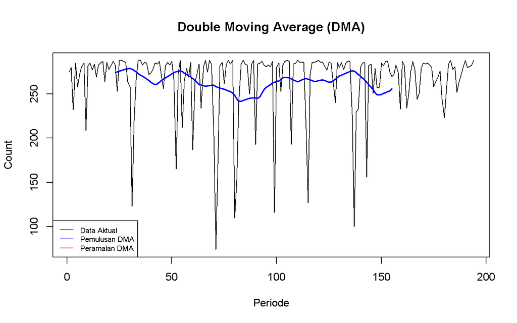

```r
plot(
  data.ts,
  type = "l",
  xlab = "Periode",
  ylab = "Count",
  main = "Double Moving Average (DMA)"
)

lines(
  c(
    rep(NA, length(train.ts) - length(sma2)),
    sma2
  ),
  col = "blue",
  lwd = 2
)

lines(
  c(
    rep(NA, length(train.ts)),
    forecast_dma
  ),
  col = "red",
  lwd = 2
)

legend(
  "bottomleft",
  c("Data Aktual", "Pemulusan DMA", "Peramalan DMA"),
  col = c("black", "blue", "red"),
  lty = 1,
  cex = 0.7
)
```

## 4. Akurasi DMA

```r
# Error DMA
error_dma <- test.ts - forecast_dma

# SSE
SSE_dma <- sum(error_dma^2)

# MSE
MSE_dma <- mean(error_dma^2)

# RMSE
RMSE_dma <- sqrt(MSE_dma)

# MAPE
MAPE_dma <- mean(
  abs(error_dma / test.ts) * 100
)

akurasi_dma <- matrix(
  c(SSE_dma, MSE_dma, RMSE_dma, MAPE_dma),
  nrow = 4
)

row.names(akurasi_dma) <- c(
  "SSE",
  "MSE",
  "RMSE",
  "MAPE"
)

colnames(akurasi_dma) <- "DMA m = 12"

akurasi_dma
```

```
##        DMA m = 12
## SSE  381633.86608
## MSE    9785.48375
## RMSE     98.92160
## MAPE     33.99186
```

Berdasarkan hasil akurasi data uji, performa DMA dievaluasi menggunakan SSE, MSE, RMSE, dan MAPE. Nilai error yang semakin kecil menunjukkan bahwa hasil peramalan DMA semakin mendekati nilai aktual. Karena DMA mempertimbangkan komponen level dan tren, metode ini dapat menghasilkan peramalan yang berbeda dari SMA.

# Exponential Smoothing

Exponential Smoothing merupakan metode pemulusan yang memberikan bobot lebih besar pada pengamatan terbaru. Bobot terhadap pengamatan yang lebih lama akan semakin kecil secara eksponensial. Metode ini dapat digunakan untuk menghasilkan nilai pemulusan dan peramalan berdasarkan data historis.

# Single Exponential Smoothing (SES)

Single Exponential Smoothing (SES) merupakan metode pemulusan yang sesuai digunakan pada data yang tidak memiliki tren yang kuat. Nilai pemulusan diperoleh dengan memberikan bobot tertentu pada data aktual terbaru dan nilai pemulusan sebelumnya.

$S_t = \alpha X_t+(1-\alpha)S_{t-1}$

Nilai parameter $\alpha$ berada pada interval 0 sampai 1. Semakin besar nilai $\alpha$, semakin besar bobot yang diberikan kepada pengamatan terbaru.

## 1. SES dengan Alpha = 0.2

```r
ses_02 <- ses(
  train.ts,
  h = length(test.ts),
  alpha = 0.2
)

ses_02
```

```
##     Point Forecast    Lo 80    Hi 80    Lo 95    Hi 95
## 156       273.6329 216.9024 330.3634 186.8711 360.3947
## 157       273.6329 215.7789 331.4869 185.1529 362.1129
## 158       273.6329 214.6769 332.5890 183.4674 363.7984
## 159       273.6329 213.5950 333.6708 181.8129 365.4530
## 160       273.6329 212.5323 334.7335 180.1876 367.0782
## 161       273.6329 211.4878 335.7781 178.5901 368.6757
## 162       273.6329 210.4605 336.8053 177.0191 370.2468
## 163       273.6329 209.4497 337.8161 175.4732 371.7927
## 164       273.6329 208.4546 338.8113 173.9512 373.3146
## 165       273.6329 207.4744 339.7915 172.4522 374.8137
## 166       273.6329 206.5085 340.7573 170.9750 376.2909
## 167       273.6329 205.5563 341.7095 169.5188 377.7471
## 168       273.6329 204.6173 342.6485 168.0826 379.1832
## 169       273.6329 203.6909 343.5750 166.6658 380.6000
```

[output cut: 25 more lines]

## 2. SES dengan Alpha = 0.7

```r
ses_07 <- ses(
  train.ts,
  h = length(test.ts),
  alpha = 0.7
)

ses_07
```

```
##     Point Forecast        Lo 80    Hi 80        Lo 95    Hi 95
## 156       272.5279 2.110033e+02 334.0526  178.4341042 366.6217
## 157       272.5279 1.974275e+02 347.6283  157.6717793 387.3841
## 158       272.5279 1.859551e+02 359.1008  140.1261829 404.9297
## 159       272.5279 1.758344e+02 369.2215  124.6478776 420.4080
## 160       272.5279 1.666769e+02 378.3789  110.6427943 434.4131
## 161       272.5279 1.582510e+02 386.8049   97.7564095 447.2994
## 162       272.5279 1.504050e+02 394.6509   85.7570233 459.2988
## 163       272.5279 1.430335e+02 402.0223   74.4833420 470.5725
## 164       272.5279 1.360597e+02 408.9962   63.8177337 481.2381
## 165       272.5279 1.294253e+02 415.6306   53.6712800 491.3846
## 166       272.5279 1.230851e+02 421.9708   43.9748279 501.0810
## 167       272.5279 1.170032e+02 428.0527   34.6733365 510.3825
## 168       272.5279 1.111503e+02 433.9056   25.7221463 519.3337
## 169       272.5279 1.055024e+02 439.5534   17.0844293 527.9714
```

[output cut: 25 more lines]

## 3. SES dengan Alpha Optimum

```r
ses_opt <- ses(
  train.ts,
  h = length(test.ts),
  alpha = NULL
)

ses_opt
```

```
##     Point Forecast    Lo 80    Hi 80    Lo 95    Hi 95
## 156       264.2648 210.2853 318.2442 181.7103 346.8192
## 157       264.2648 210.2853 318.2442 181.7103 346.8192
## 158       264.2648 210.2853 318.2442 181.7103 346.8192
## 159       264.2648 210.2853 318.2442 181.7103 346.8192
## 160       264.2648 210.2853 318.2442 181.7103 346.8192
## 161       264.2648 210.2853 318.2442 181.7103 346.8192
## 162       264.2648 210.2853 318.2442 181.7103 346.8192
## 163       264.2648 210.2853 318.2442 181.7103 346.8192
## 164       264.2648 210.2853 318.2442 181.7103 346.8192
## 165       264.2648 210.2853 318.2442 181.7103 346.8192
## 166       264.2648 210.2853 318.2442 181.7103 346.8192
## 167       264.2648 210.2853 318.2442 181.7103 346.8192
## 168       264.2648 210.2853 318.2442 181.7103 346.8192
## 169       264.2648 210.2853 318.2442 181.7103 346.8192
```

[output cut: 25 more lines]

Parameter optimum dipilih berdasarkan proses optimasi yang dilakukan oleh fungsi `ses()`. Parameter tersebut menghasilkan nilai error terkecil berdasarkan data latih.

## 4. Plot SES

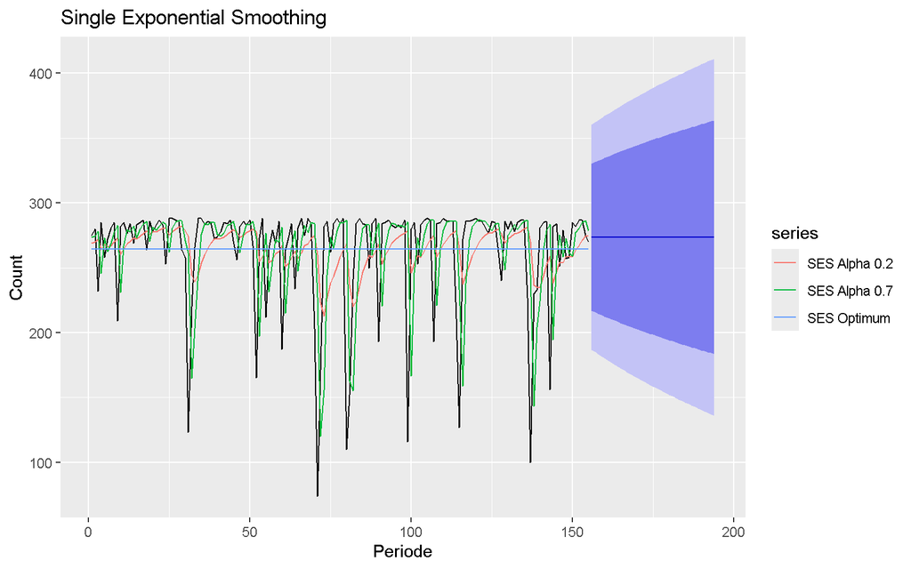

```r
autoplot(ses_02) +
  autolayer(
    fitted(ses_02),
    series = "SES Alpha 0.2"
  ) +
  autolayer(
    fitted(ses_07),
    series = "SES Alpha 0.7"
  ) +
  autolayer(
    fitted(ses_opt),
    series = "SES Optimum"
  ) +
  xlab("Periode") +
  ylab("Count") +
  ggtitle("Single Exponential Smoothing")
```

## 5. Akurasi SES

```r
# Ramalan masing-masing model
forecast_ses02 <- as.numeric(ses_02$mean)
forecast_ses07 <- as.numeric(ses_07$mean)
forecast_sesopt <- as.numeric(ses_opt$mean)

# Fungsi menghitung akurasi
hitung_akurasi <- function(aktual, ramalan) {

  error <- aktual - ramalan

  SSE <- sum(error^2)
  MSE <- mean(error^2)
  RMSE <- sqrt(MSE)
  MAPE <- mean(abs(error / aktual)) * 100

  return(
    c(
      SSE = SSE,
      MSE = MSE,
      RMSE = RMSE,
      MAPE = MAPE
    )
  )
}

akurasi_ses02 <- hitung_akurasi(
  test.ts,
  forecast_ses02
)

akurasi_ses07 <- hitung_akurasi(
  test.ts,
  forecast_ses07
)

akurasi_sesopt <- hitung_akurasi(
  test.ts,
  forecast_sesopt
)

akurasi_ses <- rbind(
  "SES Alpha 0.2" = akurasi_ses02,
  "SES Alpha 0.7" = akurasi_ses07,
  "SES Optimum" = akurasi_sesopt
)

akurasi_ses
```

```
##                    SSE      MSE     RMSE     MAPE
## SES Alpha 0.2 11949.81 306.4055 17.50444 5.223940
## SES Alpha 0.7 11741.77 301.0711 17.35140 5.296034
## SES Optimum   13205.06 338.5913 18.40085 6.212950
```

Berdasarkan hasil evaluasi, model SES dengan nilai error terkecil merupakan model SES yang memberikan hasil peramalan paling baik pada data uji. Perbandingan dilakukan menggunakan nilai SSE, MSE, RMSE, dan MAPE.

# Double Exponential Smoothing (DES)

Double Exponential Smoothing (DES) merupakan metode pemulusan yang digunakan untuk data yang memiliki kecenderungan tren. Berbeda dengan SES yang hanya melakukan pemulusan level, DES mempertimbangkan komponen level dan tren dalam menghasilkan peramalan.

## 1. DES dengan Parameter Awal

```r
des_1 <- HoltWinters(
  train.ts,
  gamma = FALSE,
  alpha = 0.2,
  beta = 0.2
)

ramalan_des1 <- forecast(
  des_1,
  h = length(test.ts)
)

des_1
```

```
## Holt-Winters exponential smoothing with trend and without seasonal component.
##
## Call:
## HoltWinters(x = train.ts, alpha = 0.2, beta = 0.2, gamma = FALSE)
##
## Smoothing parameters:
##  alpha: 0.2
##  beta : 0.2
##  gamma: FALSE
##
## Coefficients:
##        [,1]
## a 284.90226
## b   3.35425
```

## 2. DES dengan Alpha = 0.6 dan Beta = 0.3

```r
des_2 <- HoltWinters(
  train.ts,
  gamma = FALSE,
  alpha = 0.6,
  beta = 0.3
)

ramalan_des2 <- forecast(
  des_2,
  h = length(test.ts)
)

des_2
```

```
## Holt-Winters exponential smoothing with trend and without seasonal component.
##
## Call:
## HoltWinters(x = train.ts, alpha = 0.6, beta = 0.3, gamma = FALSE)
##
## Smoothing parameters:
##  alpha: 0.6
##  beta : 0.3
##  gamma: FALSE
##
## Coefficients:
##         [,1]
## a 275.146016
## b  -1.504526
```

## 3. DES dengan Parameter Optimum

```r
des_opt <- HoltWinters(
  train.ts,
  gamma = FALSE
)

ramalan_desopt <- forecast(
  des_opt,
  h = length(test.ts)
)

des_opt
```

```
## Holt-Winters exponential smoothing with trend and without seasonal component.
##
## Call:
## HoltWinters(x = train.ts, gamma = FALSE)
##
## Smoothing parameters:
##  alpha: 0.1212483
##  beta : 0.07586895
##  gamma: FALSE
##
## Coefficients:
##          [,1]
## a 267.7452107
## b   0.6079188
```

Parameter optimum diperoleh dengan membiarkan fungsi `HoltWinters()` menentukan nilai parameter pemulusan yang menghasilkan error terkecil pada data latih.

## 4. Plot DES

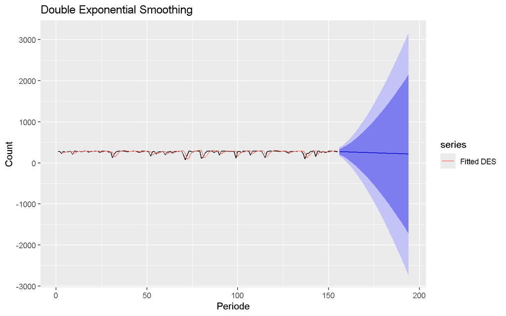

```r
autoplot(ramalan_des2) +
  autolayer(
    fitted(des_2)[,1],
    series = "Fitted DES"
  ) +
  xlab("Periode") +
  ylab("Count") +
  ggtitle("Double Exponential Smoothing")
```

## 5. Akurasi DES

```r
# Ramalan DES
forecast_des1 <- as.numeric(ramalan_des1$mean)
forecast_des2 <- as.numeric(ramalan_des2$mean)
forecast_desopt <- as.numeric(ramalan_desopt$mean)

# Menghitung akurasi
akurasi_des1 <- hitung_akurasi(
  test.ts,
  forecast_des1
)

akurasi_des2 <- hitung_akurasi(
  test.ts,
  forecast_des2
)

akurasi_desopt <- hitung_akurasi(
  test.ts,
  forecast_desopt
)

akurasi_des <- rbind(
  "DES Alpha 0.2 Beta 0.2" = akurasi_des1,
  "DES Alpha 0.6 Beta 0.3" = akurasi_des2,
  "DES Optimum" = akurasi_desopt
)

akurasi_des
```

```
##                              SSE       MSE     RMSE      MAPE
## DES Alpha 0.2 Beta 0.2 315864.22 8099.0825 89.99490 30.444679
## DES Alpha 0.6 Beta 0.3  52510.66 1346.4271 36.69369 11.431243
## DES Optimum             15086.83  386.8419 19.66830  5.667603
```

Berdasarkan hasil evaluasi, model DES dengan nilai error terkecil merupakan model yang memberikan hasil peramalan paling baik pada data uji. Perbandingan dilakukan menggunakan SSE, MSE, RMSE, dan MAPE.

# Perbandingan Metode

Perbandingan metode dilakukan untuk menentukan metode pemulusan yang memberikan hasil peramalan terbaik pada data uji. Metode yang dibandingkan adalah SMA, DMA, SES, dan DES. Ukuran utama yang digunakan dalam menentukan metode terbaik adalah **MSE**, karena semakin kecil nilai MSE maka semakin kecil rata-rata kesalahan kuadrat hasil peramalan terhadap nilai aktual.

Untuk SES dan DES digunakan model dengan parameter terbaik berdasarkan hasil evaluasi data uji.

```r
# Mengambil MSE terbaik dari SES
MSE_ses_best <- min(akurasi_ses[, "MSE"])

# Mengambil MSE terbaik dari DES
MSE_des_best <- min(akurasi_des[, "MSE"])

# Membuat tabel perbandingan
perbandingan <- data.frame(
  Metode = c(
    "SMA",
    "DMA",
    "SES",
    "DES"
  ),

  MSE_Test = c(
    MSE_sma,
    MSE_dma,
    MSE_ses_best,
    MSE_des_best
  )
)

# Mengurutkan berdasarkan MSE terkecil
perbandingan <- perbandingan[
  order(perbandingan$MSE_Test),
]

perbandingan
```

```
##   Metode  MSE_Test
## 3    SES  301.0711
## 1    SMA  314.2804
## 4    DES  386.8419
## 2    DMA 9785.4837
```

## Perbandingan Lengkap

```r
# Menentukan parameter/model terbaik
best_ses <- rownames(akurasi_ses)[
  which.min(akurasi_ses[, "MSE"])
]

best_des <- rownames(akurasi_des)[
  which.min(akurasi_des[, "MSE"])
]

# Membuat tabel perbandingan lengkap
hasil_akhir <- data.frame(
  Metode = c(
    "SMA",
    "DMA",
    best_ses,
    best_des
  ),

  SSE = c(
    SSE_sma,
    SSE_dma,
    akurasi_ses[best_ses, "SSE"],
    akurasi_des[best_des, "SSE"]
  ),

  MSE = c(
    MSE_sma,
    MSE_dma,
    akurasi_ses[best_ses, "MSE"],
    akurasi_des[best_des, "MSE"]
  ),

  RMSE = c(
    RMSE_sma,
    RMSE_dma,
    akurasi_ses[best_ses, "RMSE"],
    akurasi_des[best_des, "RMSE"]
  ),

  MAPE = c(
    MAPE_sma,
    MAPE_dma,
    akurasi_ses[best_ses, "MAPE"],
    akurasi_des[best_des, "MAPE"]
  )
)

hasil_akhir <- hasil_akhir[
  order(hasil_akhir$MSE),
]

hasil_akhir
```

```
##          Metode       SSE       MSE     RMSE      MAPE
## 3 SES Alpha 0.7  11741.77  301.0711 17.35140  5.296034
## 1           SMA  12256.94  314.2804 17.72796  5.165094
## 4   DES Optimum  15086.83  386.8419 19.66830  5.667603
## 2           DMA 381633.87 9785.4837 98.92160 33.991858
```

Berdasarkan perbandingan nilai MSE pada data uji, metode dengan nilai MSE paling kecil dipilih sebagai metode terbaik. Nilai MSE yang lebih kecil menunjukkan bahwa rata-rata kesalahan kuadrat antara nilai aktual dan hasil peramalan lebih rendah. Selain MSE, nilai SSE, RMSE, dan MAPE juga digunakan sebagai informasi pendukung dalam mengevaluasi performa masing-masing metode.

```r
# Menentukan metode terbaik
metode_terbaik <- hasil_akhir$Metode[1]

# Menampilkan hasil metode terbaik
metode_terbaik
```

```
## [1] "SES Alpha 0.7"
```

Berdasarkan hasil evaluasi, metode **SES Alpha 0.7** merupakan metode terbaik pada data uji karena menghasilkan nilai MSE paling kecil dibandingkan metode lainnya. Dengan demikian, metode tersebut memiliki hasil peramalan yang paling mendekati data aktual pada bagian data periode 195–388 yang dianalisis.

# Kesimpulan

Analisis dilakukan pada data Beijing Air Quality periode 195–388 dengan jumlah **194 observasi**. Data dibagi menjadi data latih sebanyak 155 observasi dan data uji sebanyak 39 observasi. Beberapa metode pemulusan yang diterapkan adalah Single Moving Average (SMA), Double Moving Average (DMA), Single Exponential Smoothing (SES), dan Double Exponential Smoothing (DES).

Perbandingan metode dilakukan menggunakan ukuran SSE, MSE, RMSE, dan MAPE. Metode terbaik ditentukan berdasarkan nilai MSE pada data uji karena nilai MSE yang lebih kecil menunjukkan tingkat kesalahan peramalan yang lebih rendah.

Berdasarkan hasil perbandingan, metode **SES Alpha 0.7** dipilih sebagai metode terbaik untuk data periode 195–388 karena menghasilkan nilai MSE terkecil. Hasil tersebut menunjukkan bahwa metode tersebut memberikan kemampuan peramalan yang paling baik dibandingkan metode lainnya pada bagian data yang dianalisis.